# Introduction to R

# Data Frame

In general, datasets in R are stored as data frames. The structure of a data frame is similar to a matrix but the data stored in columns of a matrix can have only the same data type while a data frame can contain multiple data types in multiple columns. A data frame has column and row names.

- Creating Data Frames & Access Components of a Data Frame

Usage: data.frame(…, row.names = NULL, check.rows = FALSE, check.names = TRUE, fix.empty.names = TRUE, stringsAsFactors = FALSE)

```r
# Creating Data Frames
names <- c('David', 'John', 'Mary')
quiz.1 <- c(89, 93, 85)
quiz.2 <- c(91, 88, 90)
Grade <- data.frame(names, quiz.1, quiz.2, stringsAsFactors = TRUE)
Grade
```

```
##   names quiz.1 quiz.2
## 1 David     89     91
## 2  John     93     88
## 3  Mary     85     90
```

```r
str(Grade) # use str() function to know the structure of the data frame
```

```
## 'data.frame':    3 obs. of  3 variables:
##  $ names : Factor w/ 3 levels "David","John",..: 1 2 3
##  $ quiz.1: num  89 93 85
##  $ quiz.2: num  91 88 90
```

We can use either $, [, or [[ operator to access columns of data frame. Here is a simple example.

```r
# extract the first variable
Grade$names
```

```
## [1] David John  Mary
## Levels: David John Mary
```

```r
Grade[,1]
```

```
## [1] David John  Mary
## Levels: David John Mary
```

```r
Grade[[1]]
```

```
## [1] David John  Mary
## Levels: David John Mary
```

We can use colnames() function to obtain all column names of the data.

```r
colnames(Grade)
```

```
## [1] "names"  "quiz.1" "quiz.2"
```

```r
colnames(Grade) <- c("names", "Quiz_1", "Quiz_2")
colnames(Grade)
```

```
## [1] "names"  "Quiz_1" "Quiz_2"
```

- Matrix-Like Operations

Elements in Data Frames can be obtained like a matrix by providing index for row and column.

```r
Grade[3,2] # the third student's first quiz grade
```

```
## [1] 85
```

```r
Grade$names[3] # the third student's name
```

```
## [1] Mary
## Levels: David John Mary
```

```r
Grade[1:2,3] # the first two students' second quiz grade
```

```
## [1] 91 88
```

```r
Grade[2,2:3] # the second student's first and second quiz grades
```

```
##   Quiz_1 Quiz_2
## 2     93     88
```

- Merging Data Frames

Usage: merge(x, y, by.x, by.y)

- x: the origin data frame
- y: the data frame to merge
- by.x: the column used for merging in x
- by.y: the column used for merging in y

```r
Grade1 <- data.frame(students = c('David', 'Gabby', 'Mary'),
                    quiz_3=c(88, 92, 85),
                    stringsAsFactors=TRUE)
Grade1
```

```
##   students quiz_3
## 1    David     88
## 2    Gabby     92
## 3     Mary     85
```

```r
merge(Grade, Grade1, by.x="names", by.y="students")
```

```
##   names Quiz_1 Quiz_2 quiz_3
## 1 David     89     91     88
## 2  Mary     85     90     85
```

**Note:** the result after merging two data frames returns only rows found in both x and y data frames. If we would like to include all rows, we need the additional argument all.x=TRUE.

```r
merge(Grade, Grade1, by.x="names", by.y="students", all.x=TRUE)
```

```
##   names Quiz_1 Quiz_2 quiz_3
## 1 David     89     91     88
## 2  John     93     88     NA
## 3  Mary     85     90     85
```

When we include the rows with no matching rows in the other data frame, NA will be assigned to the corresponding positions.

# Installing and Loading Packages

The commonly used units that people adopt to share code in R are packages. In general, a package contains code, data, documentation, tests, etc. Most people upload their packages to [CRAN](https://cran.r-project.org/), a comprehensive R Archive Network while a few people share their code on [GitHub](https://github.com/) or other web sites. It is recommended that you ONLY download packages from CRAN since these packages are well-maintained.

In order to import packages in RStudio, you need to

1. know the name of the package.
2. download the package. Here, we introduce two basic methods:
1. Click the **Packages** tab in RStudio (bottom right window) and then click Install, find Install From: and select Repository (CRAN), type the name of the package in the box under Packages (separate multiple with space or comma) and click Install.

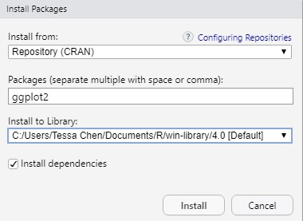

**Note:** we should leave Install dependencies checked so R will download any additional packages needed in order to use some functions or data in the package you are currently downloading.

2. In the Console window, run **install.packages(“package’s name”)**.

**Note:** It is essential to put the quotation marks around the package’s name.

3. Use library() or require() function to import the package you would like to use. Here, we show how to install the package tidyverse which is designed for data science and how to import it.

```r
install.packages("tidyverse")
library(tidyverse)
```

**Note:** 1. Sometimes, warning messages are given in the Console when installing certain packages indicating that the package was built using an older version of R. In general, these warnings can be ignored since they are still compatible with newer versions of R. 2. You only need to install a package once when the first time you need it. You can always import the package after you install it. 3. The main difference between library() and require() functions is library() returns an error if the package doesn’t exist while require() returns FALSE and gives a warning.

# Importing Data and Writing Files

In this section, we introduce two methods of importing data from some commonly used formats and write files.

1. Using the Import Dataset tab in RStudio (on the top right window).

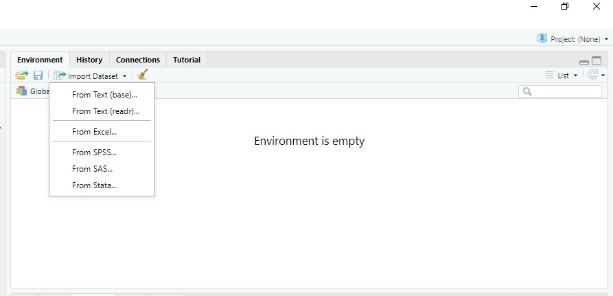

2. Using the code.

Since there are many file types, we will focus on two commonly used file types: text files and comma separated value files. We will use the package readr which is included in tidyverse as it provides a fast and convenient way to read rectangular data (e.g. csv, tsv, and fwf).

[readr](https://readr.tidyverse.org/) supports the following file types using the following functions to read files:

- read_csv(): comma separated (CSV) files
- read_csv2(): semicolon separated files
- read_delim(): general delimited files
- read_fwf(): fixed width files
- read_log(): web log files
- read_table(): tabular files where columns are separated by white-space.
- read_tsv(): tab separated files

Some Common arguments in these functions: - file: can be either a path to a file, a connection, or literal data - col_names: can be either TRUE, FALSE, or a character of column names

In general, these functions will work well. We include the path to a file, and we will obtain a tibble which is a modern reimagining of the data frame. It is much easier to navigate, view, and manipulate the contents of data using a tibble as every row is corresponding to an observation and every column is corresponding with a variable.

The following two code chunks give examples of reading data files.

```r
library(tidyverse)
df1 <- read_csv("../data/bike_sharing_data.csv")
head(df1) # use head() to read the first six rows of the data
```

```
## # A tibble: 6 x 12
##   datetime season holiday workingday weather  temp atemp humidity windspeed
##   <chr>     <dbl>   <dbl>      <dbl>   <dbl> <dbl> <dbl>    <dbl>     <dbl>
## 1 1/1/201~      1       0          0       1  9.84  14.4       81      0
## 2 1/1/201~      1       0          0       1  9.02  13.6       80      0
## 3 1/1/201~      1       0          0       1  9.02  13.6       80      0
## 4 1/1/201~      1       0          0       1  9.84  14.4       75      0
## 5 1/1/201~      1       0          0       1  9.84  14.4       75      0
## 6 1/1/201~      1       0          0       2  9.84  12.9       75      6.00
## # ... with 3 more variables: casual <dbl>, registered <dbl>, count <dbl>
```

```r
glimpse(df1) # use glimpse() to get a glimpse of the data
```

```
## Rows: 17,379
## Columns: 12
## $ datetime   <chr> "1/1/2011 0:00", "1/1/2011 1:00", "1/1/2011 2:00", "1/1/...
## $ season     <dbl> 1, 1, 1, 1, 1, 1, 1, 1, 1, 1, 1, 1, 1, 1, 1, 1, 1, 1, 1,...
## $ holiday    <dbl> 0, 0, 0, 0, 0, 0, 0, 0, 0, 0, 0, 0, 0, 0, 0, 0, 0, 0, 0,...
## $ workingday <dbl> 0, 0, 0, 0, 0, 0, 0, 0, 0, 0, 0, 0, 0, 0, 0, 0, 0, 0, 0,...
## $ weather    <dbl> 1, 1, 1, 1, 1, 2, 1, 1, 1, 1, 1, 1, 1, 2, 2, 2, 2, 2, 3,...
## $ temp       <dbl> 9.84, 9.02, 9.02, 9.84, 9.84, 9.84, 9.02, 8.20, 9.84, 13...
## $ atemp      <dbl> 14.395, 13.635, 13.635, 14.395, 14.395, 12.880, 13.635, ...
## $ humidity   <dbl> 81, 80, 80, 75, 75, 75, 80, 86, 75, 76, 76, 81, 77, 72, ...
## $ windspeed  <dbl> 0.0000, 0.0000, 0.0000, 0.0000, 0.0000, 6.0032, 0.0000, ...
## $ casual     <dbl> 3, 8, 5, 3, 0, 0, 2, 1, 1, 8, 12, 26, 29, 47, 35, 40, 41...
## $ registered <dbl> 13, 32, 27, 10, 1, 1, 0, 2, 7, 6, 24, 30, 55, 47, 71, 70...
## $ count      <dbl> 16, 40, 32, 13, 1, 1, 2, 3, 8, 14, 36, 56, 84, 94, 106, ...
```

**Note:** glimpse() is a function included in tidyverse.

The second data file: Iris.Data can be obtain from [UCI Machine Learning Repository](https://archive.ics.uci.edu/ml/datasets/Iris).

The dataset contains 3 classes of 50 instances each, where each class refers to a type of iris plant. It has 5 variables:

1. sepal length in cm
2. sepal width in cm
3. petal length in cm
4. petal width in cm
5. class: Iris Setosa, Iris Versicolour, Iris Virginica

```r
df2 <- read_delim("../data/iris.Data", delim=",", col_names = c("sepal_length", "sepal_width", "petal_length", "petal_width", "class"))
glimpse(df2)
```

```
## Rows: 150
## Columns: 5
## $ sepal_length <dbl> 5.1, 4.9, 4.7, 4.6, 5.0, 5.4, 4.6, 5.0, 4.4, 4.9, 5.4,...
## $ sepal_width  <dbl> 3.5, 3.0, 3.2, 3.1, 3.6, 3.9, 3.4, 3.4, 2.9, 3.1, 3.7,...
## $ petal_length <dbl> 1.4, 1.4, 1.3, 1.5, 1.4, 1.7, 1.4, 1.5, 1.4, 1.5, 1.5,...
## $ petal_width  <dbl> 0.2, 0.2, 0.2, 0.2, 0.2, 0.4, 0.3, 0.2, 0.2, 0.1, 0.2,...
## $ class        <chr> "Iris-setosa", "Iris-setosa", "Iris-setosa", "Iris-set...
```

**Note:** In many programming languages like C, C++, Java, MatLab, Python, Perl, R, a backslash, \, works as an escape character in strings. So in these languages, we need to use either slash, /, or double backslash, \\, in the string in order to get a single backslash for a path.

Similarly, [readr](https://readr.tidyverse.org/reference/write_delim.html) provides the following functions to write files:

- write_csv(): comma separated (CSV) files
- write_csv2(): semicolon separated files
- write_delim(): general delimited files
- write_excel_csv
- write_excel_csv2
- write_tsv: tab separated files

Some Common arguments in these functions:

- x: a data frame
- path: Path or connection to write to (including the file name).
- delim: delimiter used to separate values.
- na: string used for missing values. Defaults to NA.
- append: if FALSE, the function overwrites existing file. If TRUE, it appends to existing file. A new file will be created if the file does not exist.
- col_names: If TRUE, write columns names at the top of the file.

```r
write_csv(df1, "../data/newfile.csv")
```

# Session 3: Basic Graphical Displays

# Brief Overview

In this session, we will use the data diamonds which contains prices of over 50,000 round cut diamonds to study how to make the following graphical displays. This data is included in tidyverse.

- Categorical Data
  - Bar Chart
  - Pie Chart
- Quantitative Data
  - Histogram
  - Boxplot
  - Scatterplot
  - Line

Here is a list of common arguments

- col: a vector of colors
- main: title for the plot
- xlim or ylim: limits for the x or y axis
- xlab or ylab: a label for the x axis
- font: font used for text, 1=plain; 2=bold; 3=italic, 4=bold italic
- font.axis: font used for axis
- cex.axis: font size for x and y axes
- font.lab: font for x and y labels
- cex.lab: font size for x and y labels

# Bar Chart

Bar chart is the graphical display good for the general audience. Here we study the distribution of the quality of the cut in the data.

Usage: barplot(height, …)

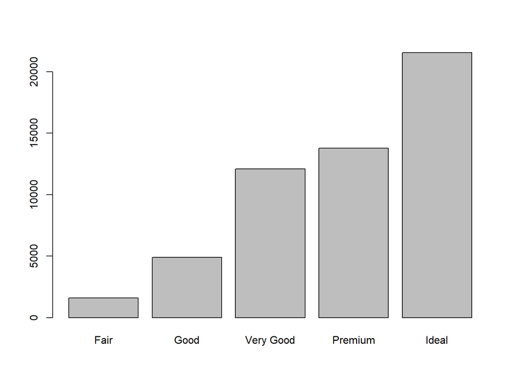

```r
barplot(table(diamonds$cut))
```

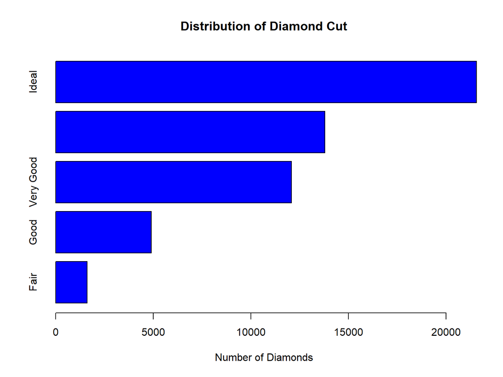

```r
barplot(table(diamonds$cut), col="blue", main="Distribution of Diamond Cut", horiz=TRUE, xlab="Number of Diamonds")
```

**Note:**

1. One can use names to change the names appearing under each bar. For example, names=c(“F”, “G”, “VG”, “P”, “I”).
2. We can use RGB color code to assign colors.

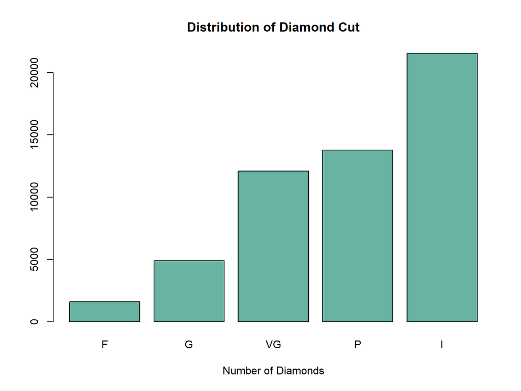

```r
barplot(table(diamonds$cut), col="#69b3a2", main="Distribution of Diamond Cut", xlab="Number of Diamonds", names=c("F", "G", "VG", "P", "I"))
```

# Pie Chart

Similarly, we can use pie chart to study the distribution of the diamond color, from D (best) to J (worst).

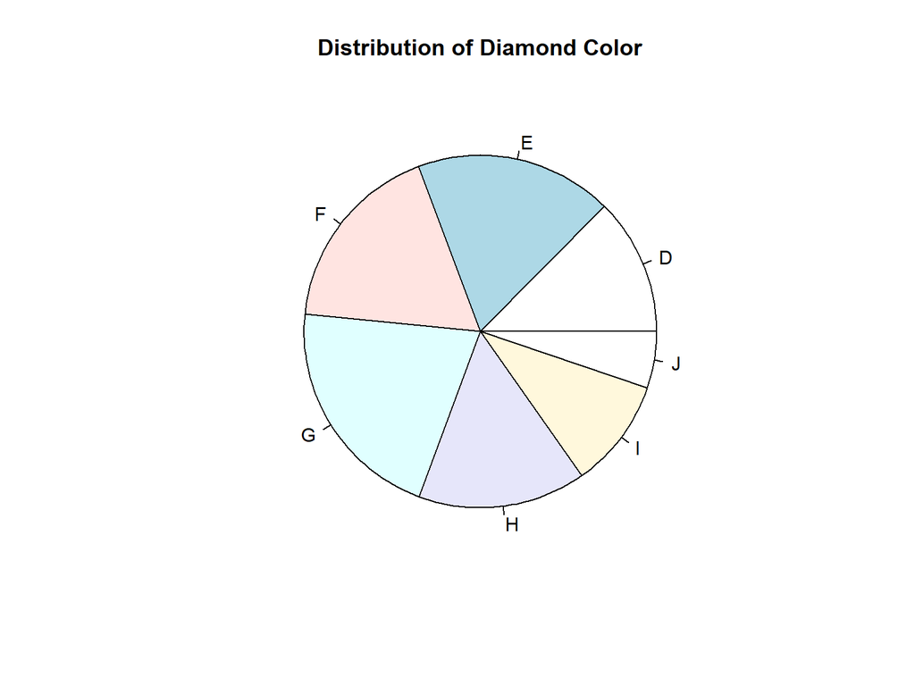

```r
pie(table(diamonds$color), main="Distribution of Diamond Color")
```

The following code chunk shows an advanced setting.

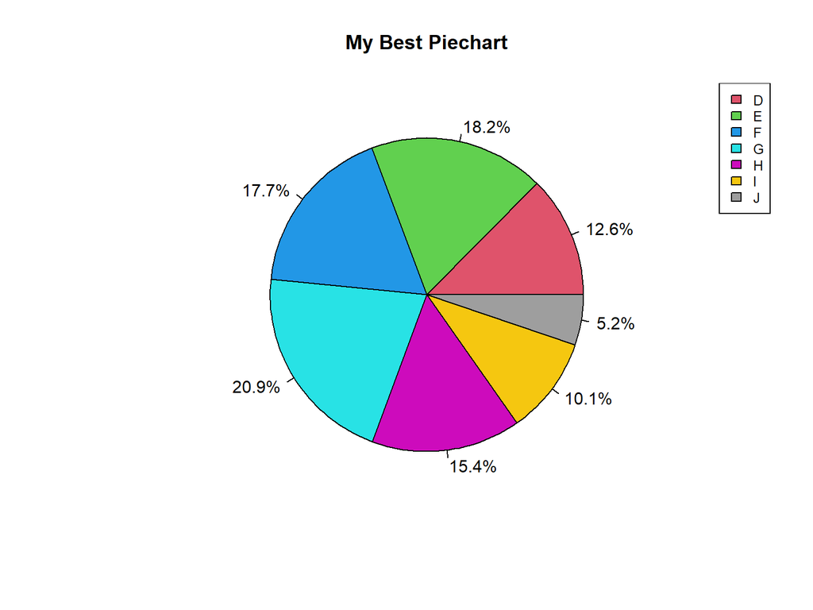

```r
H <- table(diamonds$color)
percent <- round(100*H/sum(H), 1) # calculate percentages
pie_labels <- paste(percent, "%", sep="") # include %
pie(H, main="My Best Piechart", labels=pie_labels, col = 2:8)
legend("topright", c("D","E","F","G","H","I","J"), cex=0.8, fill=2:8)
```

**Tip:** Use color palette to choose colors.

# Histogram

Histogram is used when we want to study the distribution of a quantitative variable. Here we study the distribution of the prices in the data.

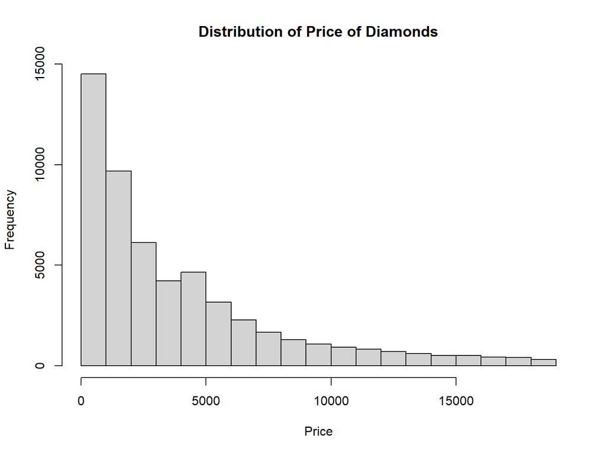

```r
hist(diamonds$price, main="Distribution of Price of Diamonds", xlab="Price")
```

# Boxplot

Here we talk about another graphical display that can be used to study the distribution of a quantitative variable: box and whisker plot (boxplot).

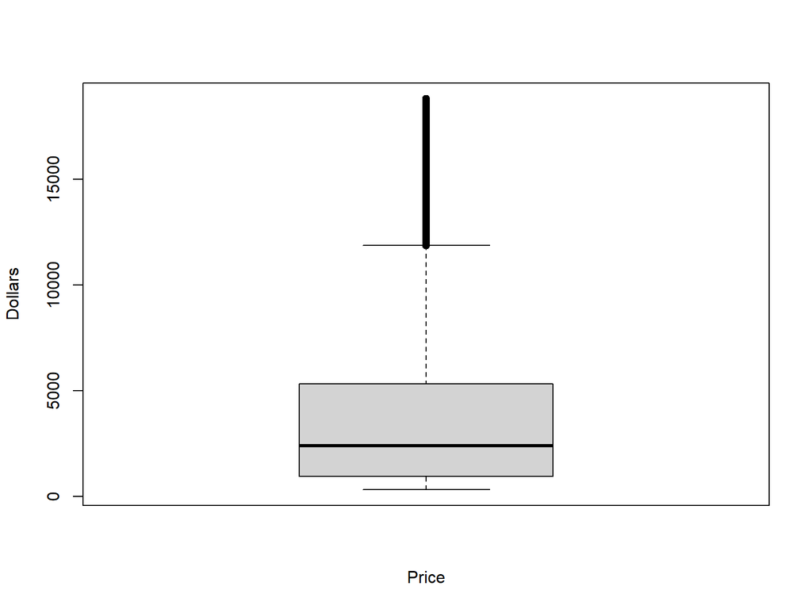

```r
boxplot(diamonds$price, xlab="Price", ylab="Dollars")
```

In order to know how this can be done, we need to know how to define a formula in R.

Useage: A ~ B

- A: response variable
- B: explanatory variables

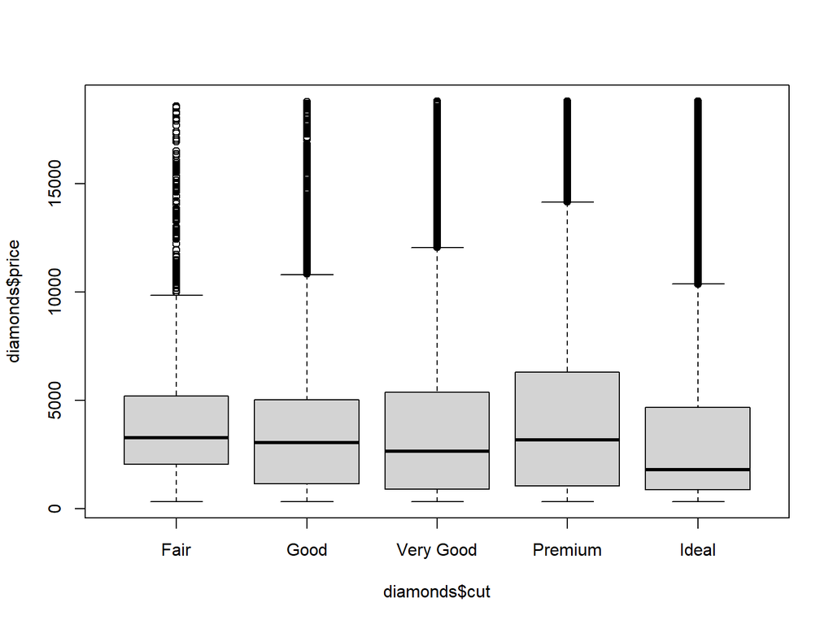

```r
boxplot(diamonds$price~diamonds$cut)
```

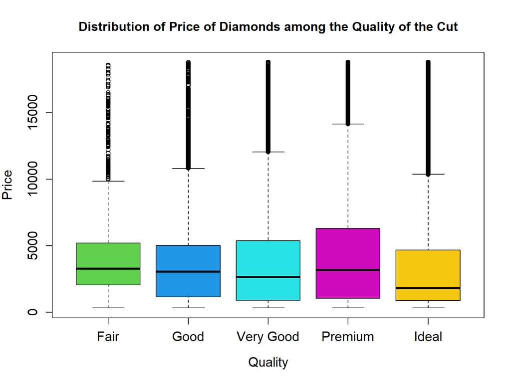

```r
boxplot(diamonds$price ~ diamonds$cut, main="Distribution of Price of Diamonds among the Quality of the Cut", xlab="Quality", ylab="Price", col=11:15, cex.lab=1.25, cex.axis=1.25)
```

We can use the argument data to indicate that variables used are from a given data.

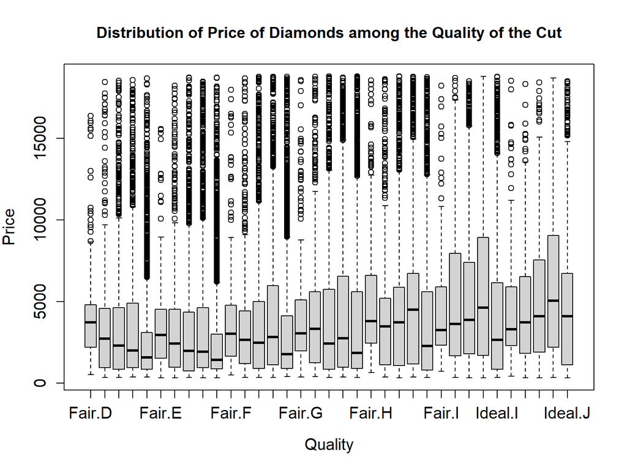

```r
boxplot(price ~ cut + color, data = diamonds, main="Distribution of Price of Diamonds among the Quality of the Cut", xlab="Quality", ylab="Price",  cex.lab=1.25, cex.axis=1.25)
```

The above plot is only for the demonstration purpose. We can see that not names for all categories are shown on the plot which should be improved.

# Scatterplot

When we want to study the relationship of two quantitative variables, a scatterplot can be used. Here we study the relationship of the diamond price against its weight.

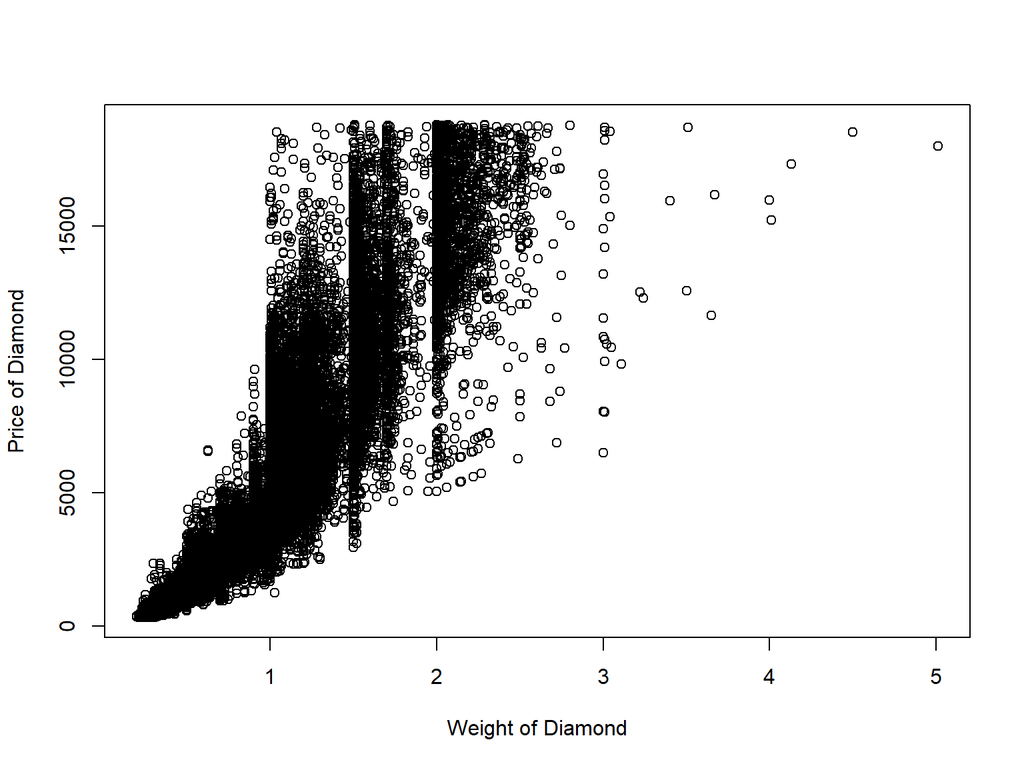

```r
plot(price ~ carat, data=diamonds, xlab="Weight of Diamond", ylab="Price of Diamond")
```

# Line Plot

When we want to show how a quantitative variable changes over a period of time. a line plot can be used. Line plots can also be used to compare changes over the same period of time for several groups. Since diamonds dataset is not time series data, it is not appropriate to use line plot. In the following code chunk, we create a data frame using the forecasted highest temperatures from July 13 to July 22 ([The Weather Channel](https://weather.com/)).

In order to graph a line plot, we need to know two additional arguments

- type: “p” to draw only points; “l” to draw only lines; “o” to draw both points and lines
- lty: line types. 0=blank; 1=solid; 2=dashed; 4=dotdash, 5=longdash, 6=twodash

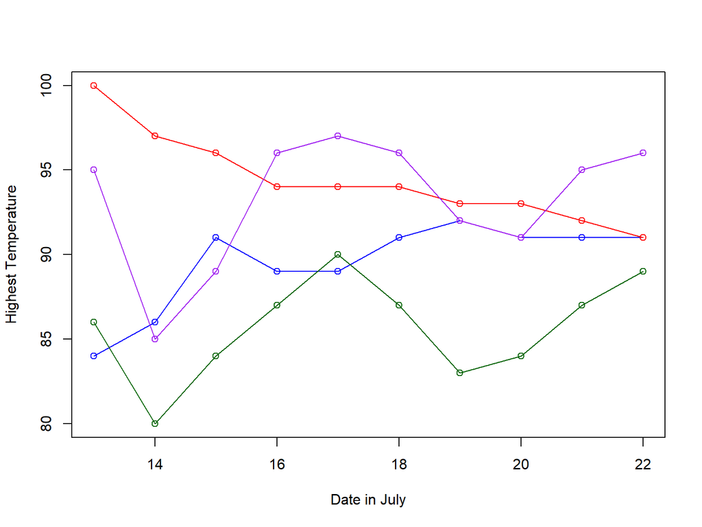

```r
Date <- 13:22
Dayton_OH <- c(84, 86, 91, 89, 89, 91, 92, 91, 91, 91)
Houston_TX <- c(100, 97, 96, 94, 94, 94, 93, 93, 92, 91)
Denver_CO <- c(95, 85, 89, 96, 97, 96, 92, 91, 95, 96)
Fargo_ND <- c(86, 80, 84, 87, 90, 87, 83, 84, 87, 89)
df <- data.frame(Date, Dayton_OH, Houston_TX, Denver_CO, Fargo_ND)

plot(Date, Dayton_OH, type="o", col="blue", xlab="Date in July", ylab="Highest Temperature", ylim=c(80, 100))
lines(Date, Houston_TX, type="o", col="red")
lines(Date, Denver_CO, type="o", col="purple")
lines(Date, Fargo_ND, type="o", col="darkgreen")
```

# Session 4: Data Manipulation

# Brief Overview

In this session, we will talk about data manipulation using R package tidyverse. This package contains a collection of R packages that help us doing data management & exploration. The key packages in tidyverse are:

- dplyr: data manipulation
- ggplot2: data visualization
- purr: functional programming toolkit
- readr: read data and write files
- tibble: simple data frame
- tidyr: data management

In this session, we will focus on the following key functions in dplyr using the bike_sharing_data.csv.

- arrange()
- filter()
- group_by()
- mutate()
- select()
- summarize()

# Pipe

In other to handle the data processing well in data science, it is essential to know the use of pipes. Pipes are great tool for presenting a sequence of multiple operations and therefore, pipes increase readability of the code. The pipe, %>%, is from the package magrittr and it is loaded automatically when tidyverse is loaded.

The logic when using pipe: object %>% function1 %>% function 2….

First, we load the package, check conflict functions and import the bike_sharing_data.csv.

```r
library(tidyverse)
library(conflicted)
conflict_prefer("select", "dplyr")
```

```
## [conflicted] Will prefer dplyr::select over any other package
```

```r
conflict_prefer("filter", "dplyr")
```

```
## [conflicted] Will prefer dplyr::filter over any other package
```

```r
df <- read_csv("../data/bike_sharing_data.csv")
```

Now we need to understand each variable before we move on. In this data, we have 12 variables ([UCI Machine Learning Repository](https://archive.ics.uci.edu/ml/datasets/bike+sharing+dataset)).

- datetime: date and time of the event
- season: 1:spring, 2:summer, 3:fall, 4:winter
- holiday: 1: holiday, 0: not holiday
- workingday: 1: neither weekend nor holiday, 0: otherwise
- weather 1: Clear, Few clouds, Partly cloudy, Partly cloudy 2: Mist + Cloudy, Mist + Broken clouds, Mist + Few clouds, Mist 3: Light Snow, Light Rain + Thunderstorm + Scattered clouds, Light Rain + Scattered clouds 4: Heavy Rain + Ice Pallets + Thunderstorm + Mist, Snow + Fog
- temp: Normalized temperature in Celsius
- atemp: Normalized feeling temperature in Celsius
- humidity: Normalized humidity
- windspeed: Normalized humidity
- casual: count of casual users
- registered: count of registered users
- count: count of total rental bikes including casual and registered

# arrange()

arrange() is used when we want to sort a dataset by a variable. If more variables are specified for sorting a dataset, the variables entered first taking priority over those come later. The following code chunk gives an example that sorts the bike_sharing_data by its temperature and humidity so we can compare the distribution of count in the data.

```r
df1 <- df %>% arrange(temp, humidity)
df1[1:10,c("datetime","temp", "humidity", "count")] # print the first 10 rows to check the result
```

```
## # A tibble: 10 x 4
##    datetime        temp humidity count
##    <chr>          <dbl>    <dbl> <dbl>
##  1 1/4/2012 2:00   0.82       34     1
##  2 1/4/2012 3:00   0.82       34     1
##  3 1/4/2012 4:00   0.82       41     2
##  4 1/4/2012 5:00   0.82       41    14
##  5 1/4/2012 6:00   0.82       41    59
##  6 1/22/2011 6:00  0.82       44     4
##  7 1/22/2011 7:00  0.82       44    13
##  8 1/22/2011 8:00  0.82       44    28
##  9 1/4/2012 7:00   0.82       44   152
## 10 1/4/2012 8:00   0.82       44   315
```

Some potential questions we may be interested: is there any association between the count of bike sharing and the temperature or the humidity or both?

**Note:**

1. We can save the data frame back to the original data frame after sorting the data.
2. Use desc() for sorting data via descending order. For example, df %>% arrange(temp, desc(humidity))

# filter()

filter() is used when we want to filter out entries in a column based o a logical condition. If we would like to study how popular the bike sharing program (count) is during when we have holidays, we can use filter() to filter out data for holidays.

```r
table(df$holiday)
```

```
##
##     0     1
## 16879   500
```

```r
df2 <- df %>% filter(holiday==1)
df2$count[1:10]
```

```
##  [1] 17 16  8  2  3  1  5 13 33 47
```

```r
summary(df2$count) # find the summary statistics for count for holidays
```

```
##    Min. 1st Qu.  Median    Mean 3rd Qu.    Max.
##    1.00   34.75  120.00  168.37  265.25  712.00
```

```r
summary(df$count) # the summary statistics for the original data
```

```
##    Min. 1st Qu.  Median    Mean 3rd Qu.    Max.
##       1      42     141     187     277     977
```

What did you find by comparing the summary statistics between holidays’ data and the original data?

Here is an advanced example that shows how we can filter out data for holidays in season 2 and the temperature is higher than 20 degrees.

```r
df3 <- df %>% filter(holiday==1, season==2, temp>20)
dim(df3)
```

```
## [1] 81 12
```

```r
summary(df3$count)
```

```
##    Min. 1st Qu.  Median    Mean 3rd Qu.    Max.
##     6.0    84.0   243.0   229.2   337.0   712.0
```

```r
summary(df2$count)
```

```
##    Min. 1st Qu.  Median    Mean 3rd Qu.    Max.
##    1.00   34.75  120.00  168.37  265.25  712.00
```

Or we can filter out data for holidays in season 2 or season 3 and the temperature is higher than 20 degrees.

```r
df4 <- df %>% filter(holiday==1, season==2|season==3, temp>20)
dim(df4)
```

```
## [1] 177  12
```

```r
summary(df4$count)
```

```
##    Min. 1st Qu.  Median    Mean 3rd Qu.    Max.
##     4.0    60.0   229.0   233.9   375.0   712.0
```

```r
summary(df3$count)
```

```
##    Min. 1st Qu.  Median    Mean 3rd Qu.    Max.
##     6.0    84.0   243.0   229.2   337.0   712.0
```

# group_by() & summarize()

group_by() is used to group rows by one or more variables, giving priority to the variable entered first. For example, if we would like to study the weather effect on the bike sharing program, we can group rows by weather categories.

```r
table(df$weather)
```

```
##
##     1     2     3     4
## 11413  4544  1419     3
```

```r
df5 <- df %>% group_by(weather)
df5
```

```
## # A tibble: 17,379 x 12
## # Groups:   weather [4]
##    datetime season holiday workingday weather  temp atemp humidity windspeed
##    <chr>     <dbl>   <dbl>      <dbl>   <dbl> <dbl> <dbl>    <dbl>     <dbl>
##  1 1/1/201~      1       0          0       1  9.84  14.4       81      0
##  2 1/1/201~      1       0          0       1  9.02  13.6       80      0
##  3 1/1/201~      1       0          0       1  9.02  13.6       80      0
##  4 1/1/201~      1       0          0       1  9.84  14.4       75      0
##  5 1/1/201~      1       0          0       1  9.84  14.4       75      0
##  6 1/1/201~      1       0          0       2  9.84  12.9       75      6.00
##  7 1/1/201~      1       0          0       1  9.02  13.6       80      0
##  8 1/1/201~      1       0          0       1  8.2   12.9       86      0
##  9 1/1/201~      1       0          0       1  9.84  14.4       75      0
## 10 1/1/201~      1       0          0       1 13.1   17.4       76      0
## # ... with 17,369 more rows, and 3 more variables: casual <dbl>,
## #   registered <dbl>, count <dbl>
```

The result shows the original data but indicates a group, weather, in our example. In general, summarize() function is used together with group_by() as we group rows for some purposes. For example, we can study the average measures (temp, atemp, humidity, windspeed) for the quantitative variables with different weather condition.

```r
table(df$weather)
```

```
##
##     1     2     3     4
## 11413  4544  1419     3
```

```r
df6 <- df %>% group_by(weather) %>% summarize(ave_temp = mean(temp),
                                              ave_atemp = mean(atemp),
                                              ave_atemp = mean(humidity),
                                              ave_windspeed = mean(windspeed),
                                              cases = n())
df6
```

```
## # A tibble: 4 x 5
##   weather ave_temp ave_atemp ave_windspeed cases
##     <dbl>    <dbl>     <dbl>         <dbl> <int>
## 1       1    21.0       57.4          12.8 11413
## 2       2    19.5       69.9          12.1  4544
## 3       3    18.7       82.8          14.7  1419
## 4       4     7.65      88.3          13.7     3
```

# mutate()

mutate() is used when we would like to add a new variable / column using the other variables in the data. The following code chunk shows how we convert the temperature (temp) and feeling temperature (atemp) from Celsius to Fahrenheit using the equation
$$F = \frac{9}{5}\times C+32$$
in the data and add two columns to the dataset.

```r
df7 <- df %>% mutate(F_temp=9/5*temp+32, F_atemp=9/5*atemp+32)
glimpse(df7)
```

```
## Rows: 17,379
## Columns: 14
## $ datetime   <chr> "1/1/2011 0:00", "1/1/2011 1:00", "1/1/2011 2:00", "1/1/...
## $ season     <dbl> 1, 1, 1, 1, 1, 1, 1, 1, 1, 1, 1, 1, 1, 1, 1, 1, 1, 1, 1,...
## $ holiday    <dbl> 0, 0, 0, 0, 0, 0, 0, 0, 0, 0, 0, 0, 0, 0, 0, 0, 0, 0, 0,...
## $ workingday <dbl> 0, 0, 0, 0, 0, 0, 0, 0, 0, 0, 0, 0, 0, 0, 0, 0, 0, 0, 0,...
## $ weather    <dbl> 1, 1, 1, 1, 1, 2, 1, 1, 1, 1, 1, 1, 1, 2, 2, 2, 2, 2, 3,...
## $ temp       <dbl> 9.84, 9.02, 9.02, 9.84, 9.84, 9.84, 9.02, 8.20, 9.84, 13...
## $ atemp      <dbl> 14.395, 13.635, 13.635, 14.395, 14.395, 12.880, 13.635, ...
## $ humidity   <dbl> 81, 80, 80, 75, 75, 75, 80, 86, 75, 76, 76, 81, 77, 72, ...
## $ windspeed  <dbl> 0.0000, 0.0000, 0.0000, 0.0000, 0.0000, 6.0032, 0.0000, ...
## $ casual     <dbl> 3, 8, 5, 3, 0, 0, 2, 1, 1, 8, 12, 26, 29, 47, 35, 40, 41...
## $ registered <dbl> 13, 32, 27, 10, 1, 1, 0, 2, 7, 6, 24, 30, 55, 47, 71, 70...
## $ count      <dbl> 16, 40, 32, 13, 1, 1, 2, 3, 8, 14, 36, 56, 84, 94, 106, ...
## $ F_temp     <dbl> 49.712, 48.236, 48.236, 49.712, 49.712, 49.712, 48.236, ...
## $ F_atemp    <dbl> 57.911, 56.543, 56.543, 57.911, 57.911, 55.184, 56.543, ...
```

We also can use a logical statement to add a new variable in the data.

```r
df8 <- df7 %>% mutate(temp_level=ifelse(F_temp>85, "high", "low"))
glimpse(df8)
```

```
## Rows: 17,379
## Columns: 15
## $ datetime   <chr> "1/1/2011 0:00", "1/1/2011 1:00", "1/1/2011 2:00", "1/1/...
## $ season     <dbl> 1, 1, 1, 1, 1, 1, 1, 1, 1, 1, 1, 1, 1, 1, 1, 1, 1, 1, 1,...
## $ holiday    <dbl> 0, 0, 0, 0, 0, 0, 0, 0, 0, 0, 0, 0, 0, 0, 0, 0, 0, 0, 0,...
## $ workingday <dbl> 0, 0, 0, 0, 0, 0, 0, 0, 0, 0, 0, 0, 0, 0, 0, 0, 0, 0, 0,...
## $ weather    <dbl> 1, 1, 1, 1, 1, 2, 1, 1, 1, 1, 1, 1, 1, 2, 2, 2, 2, 2, 3,...
## $ temp       <dbl> 9.84, 9.02, 9.02, 9.84, 9.84, 9.84, 9.02, 8.20, 9.84, 13...
## $ atemp      <dbl> 14.395, 13.635, 13.635, 14.395, 14.395, 12.880, 13.635, ...
## $ humidity   <dbl> 81, 80, 80, 75, 75, 75, 80, 86, 75, 76, 76, 81, 77, 72, ...
## $ windspeed  <dbl> 0.0000, 0.0000, 0.0000, 0.0000, 0.0000, 6.0032, 0.0000, ...
## $ casual     <dbl> 3, 8, 5, 3, 0, 0, 2, 1, 1, 8, 12, 26, 29, 47, 35, 40, 41...
## $ registered <dbl> 13, 32, 27, 10, 1, 1, 0, 2, 7, 6, 24, 30, 55, 47, 71, 70...
## $ count      <dbl> 16, 40, 32, 13, 1, 1, 2, 3, 8, 14, 36, 56, 84, 94, 106, ...
## $ F_temp     <dbl> 49.712, 48.236, 48.236, 49.712, 49.712, 49.712, 48.236, ...
## $ F_atemp    <dbl> 57.911, 56.543, 56.543, 57.911, 57.911, 55.184, 56.543, ...
## $ temp_level <chr> "low", "low", "low", "low", "low", "low", "low", "low", ...
```

```r
table(df8$temp_level)
```

```
##
##  high   low
##  2685 14694
```

# select()

select() is used when we would like to obtain several variables in the data. For example, if we would like to focus on the study of the quantitative variables in the bike sharing data, we can use the select() function to include all quantitative variables.

```r
df9 <- df %>% select(temp, atemp, humidity, windspeed, casual, registered, count)
glimpse(df9)
```

```
## Rows: 17,379
## Columns: 7
## $ temp       <dbl> 9.84, 9.02, 9.02, 9.84, 9.84, 9.84, 9.02, 8.20, 9.84, 13...
## $ atemp      <dbl> 14.395, 13.635, 13.635, 14.395, 14.395, 12.880, 13.635, ...
## $ humidity   <dbl> 81, 80, 80, 75, 75, 75, 80, 86, 75, 76, 76, 81, 77, 72, ...
## $ windspeed  <dbl> 0.0000, 0.0000, 0.0000, 0.0000, 0.0000, 6.0032, 0.0000, ...
## $ casual     <dbl> 3, 8, 5, 3, 0, 0, 2, 1, 1, 8, 12, 26, 29, 47, 35, 40, 41...
## $ registered <dbl> 13, 32, 27, 10, 1, 1, 0, 2, 7, 6, 24, 30, 55, 47, 71, 70...
## $ count      <dbl> 16, 40, 32, 13, 1, 1, 2, 3, 8, 14, 36, 56, 84, 94, 106, ...
```

This action is equivalent to dropping other variables in the data.

```r
df10 <- df %>% select(-c(datetime, season, holiday, workingday, weather))
glimpse(df10)
```

```
## Rows: 17,379
## Columns: 7
## $ temp       <dbl> 9.84, 9.02, 9.02, 9.84, 9.84, 9.84, 9.02, 8.20, 9.84, 13...
## $ atemp      <dbl> 14.395, 13.635, 13.635, 14.395, 14.395, 12.880, 13.635, ...
## $ humidity   <dbl> 81, 80, 80, 75, 75, 75, 80, 86, 75, 76, 76, 81, 77, 72, ...
## $ windspeed  <dbl> 0.0000, 0.0000, 0.0000, 0.0000, 0.0000, 6.0032, 0.0000, ...
## $ casual     <dbl> 3, 8, 5, 3, 0, 0, 2, 1, 1, 8, 12, 26, 29, 47, 35, 40, 41...
## $ registered <dbl> 13, 32, 27, 10, 1, 1, 0, 2, 7, 6, 24, 30, 55, 47, 71, 70...
## $ count      <dbl> 16, 40, 32, 13, 1, 1, 2, 3, 8, 14, 36, 56, 84, 94, 106, ...
```

# Other Useful functions

In this subsection, we talk about other useful functions.

### drop_na() function

drop_na() is used when we would like to drop rows containing missing values. Since bike sharing data has no missing values, the R built-in data airquality is used here. First, we can use sum() and is.na() functions together to check if there is any missing values in the data.

```r
sum(is.na(df)) # returns 0 if there is no missing values
```

```
## [1] 0
```

```r
sum(is.na(airquality))
```

```
## [1] 44
```

We can find that there are 44 missing values in the data. Now we can use drop_na() to drop rows containing missing values.

```r
df_air <- airquality %>% drop_na()
sum(is.na(df_air))
```

```
## [1] 0
```

### Mutate Multiple Columns

Here we introduce a family of mutate related functions: mutate_all(), mutate_at(), mutate_if().

- mutate_all() is used when we want to edit all columns.
  - Usage: mutate_all(data, .funs, …)

The following code chunk shows how we can scale each variable ($\frac{x-\bar{x}}{s_x}$, $\bar{x}$ is the sample mean and $s_x$ is the corresponding standard deviation) in the data airquality.

```r
air_scale <- airquality %>% mutate_all(scale)
```

- mutate_at() is used when we want to edit specific columns.
  - Usage: mutate_at(data, .vars, .funs, …, .cols = NULL)

The following code chunk shows how we can transform the data types of season, holiday, workingday, and weather to factor in the bike sharing data.

```r
glimpse(df) # check the original data structure again
```

```
## Rows: 17,379
## Columns: 12
## $ datetime   <chr> "1/1/2011 0:00", "1/1/2011 1:00", "1/1/2011 2:00", "1/1/...
## $ season     <dbl> 1, 1, 1, 1, 1, 1, 1, 1, 1, 1, 1, 1, 1, 1, 1, 1, 1, 1, 1,...
## $ holiday    <dbl> 0, 0, 0, 0, 0, 0, 0, 0, 0, 0, 0, 0, 0, 0, 0, 0, 0, 0, 0,...
## $ workingday <dbl> 0, 0, 0, 0, 0, 0, 0, 0, 0, 0, 0, 0, 0, 0, 0, 0, 0, 0, 0,...
## $ weather    <dbl> 1, 1, 1, 1, 1, 2, 1, 1, 1, 1, 1, 1, 1, 2, 2, 2, 2, 2, 3,...
## $ temp       <dbl> 9.84, 9.02, 9.02, 9.84, 9.84, 9.84, 9.02, 8.20, 9.84, 13...
## $ atemp      <dbl> 14.395, 13.635, 13.635, 14.395, 14.395, 12.880, 13.635, ...
## $ humidity   <dbl> 81, 80, 80, 75, 75, 75, 80, 86, 75, 76, 76, 81, 77, 72, ...
## $ windspeed  <dbl> 0.0000, 0.0000, 0.0000, 0.0000, 0.0000, 6.0032, 0.0000, ...
## $ casual     <dbl> 3, 8, 5, 3, 0, 0, 2, 1, 1, 8, 12, 26, 29, 47, 35, 40, 41...
## $ registered <dbl> 13, 32, 27, 10, 1, 1, 0, 2, 7, 6, 24, 30, 55, 47, 71, 70...
## $ count      <dbl> 16, 40, 32, 13, 1, 1, 2, 3, 8, 14, 36, 56, 84, 94, 106, ...
```

```r
df11 <- df %>% mutate_at(c("season", "holiday", "workingday", "weather"), as.factor)
glimpse(df11) # check the new data structure
```

```
## Rows: 17,379
## Columns: 12
## $ datetime   <chr> "1/1/2011 0:00", "1/1/2011 1:00", "1/1/2011 2:00", "1/1/...
## $ season     <fct> 1, 1, 1, 1, 1, 1, 1, 1, 1, 1, 1, 1, 1, 1, 1, 1, 1, 1, 1,...
## $ holiday    <fct> 0, 0, 0, 0, 0, 0, 0, 0, 0, 0, 0, 0, 0, 0, 0, 0, 0, 0, 0,...
## $ workingday <fct> 0, 0, 0, 0, 0, 0, 0, 0, 0, 0, 0, 0, 0, 0, 0, 0, 0, 0, 0,...
## $ weather    <fct> 1, 1, 1, 1, 1, 2, 1, 1, 1, 1, 1, 1, 1, 2, 2, 2, 2, 2, 3,...
## $ temp       <dbl> 9.84, 9.02, 9.02, 9.84, 9.84, 9.84, 9.02, 8.20, 9.84, 13...
## $ atemp      <dbl> 14.395, 13.635, 13.635, 14.395, 14.395, 12.880, 13.635, ...
## $ humidity   <dbl> 81, 80, 80, 75, 75, 75, 80, 86, 75, 76, 76, 81, 77, 72, ...
## $ windspeed  <dbl> 0.0000, 0.0000, 0.0000, 0.0000, 0.0000, 6.0032, 0.0000, ...
## $ casual     <dbl> 3, 8, 5, 3, 0, 0, 2, 1, 1, 8, 12, 26, 29, 47, 35, 40, 41...
## $ registered <dbl> 13, 32, 27, 10, 1, 1, 0, 2, 7, 6, 24, 30, 55, 47, 71, 70...
## $ count      <dbl> 16, 40, 32, 13, 1, 1, 2, 3, 8, 14, 36, 56, 84, 94, 106, ...
```

- mutate_if() is used when we want to edit specific columns with a predicate function.
  - Usage: mutate_if(data, .predicate, .funs, …)

The following code chunk shows how we can scale the quantitative variables in the bike sharing data and round values to the first decimal place.

```r
df11 <- df11 %>% mutate_if(is.numeric, scale) %>% mutate_if(is.numeric, round, digits = 1)
df11
```

```
## # A tibble: 17,379 x 12
##    datetime season holiday workingday weather temp[,1] atemp[,1] humidity[,1]
##    <chr>    <fct>  <fct>   <fct>      <fct>      <dbl>     <dbl>        <dbl>
##  1 1/1/201~ 1      0       0          1           -1.3      -1.1          0.9
##  2 1/1/201~ 1      0       0          1           -1.4      -1.2          0.9
##  3 1/1/201~ 1      0       0          1           -1.4      -1.2          0.9
##  4 1/1/201~ 1      0       0          1           -1.3      -1.1          0.6
##  5 1/1/201~ 1      0       0          1           -1.3      -1.1          0.6
##  6 1/1/201~ 1      0       0          2           -1.3      -1.3          0.6
##  7 1/1/201~ 1      0       0          1           -1.4      -1.2          0.9
##  8 1/1/201~ 1      0       0          1           -1.5      -1.3          1.2
##  9 1/1/201~ 1      0       0          1           -1.3      -1.1          0.6
## 10 1/1/201~ 1      0       0          1           -0.9      -0.7          0.7
## # ... with 17,369 more rows, and 4 more variables: windspeed[,1] <dbl>,
## #   casual[,1] <dbl>, registered[,1] <dbl>, count[,1] <dbl>
```

**Note:** Why Scaling or Standadizing values?

1. “How unusual is a value/observation?” The answer depends on the units of measurement.
2. Variables measured at different scales don’t contribute equally to the analysis.

R Documentation. 2020. “R: Quotes.” https://stat.ethz.ch/R-manual/R-devel/library/base/html/Quotes.html.

Xie, Yihui, Joseph J Allaire, and Garrett Grolemund. 2018. *R Markdown: The Definitive Guide*. CRC Press.